도입0–1분

## AI 시대, 공학자는 무엇을 위해 배우고 일하는가

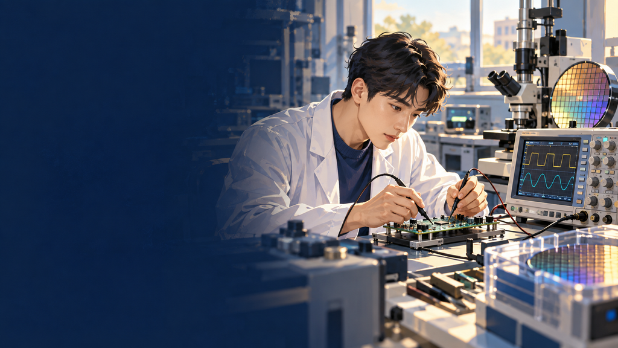

강의용 생성 일러스트: 실험하는 공학자

# AI 시대, 공학자는 무엇을 위해 배우고 일하는가

지식에서 경험으로, 경험에서 데이터로

김임환 · 설계특론 · 60분 강의

도입1–5분

## 여러분은 왜 여기에 있습니까?

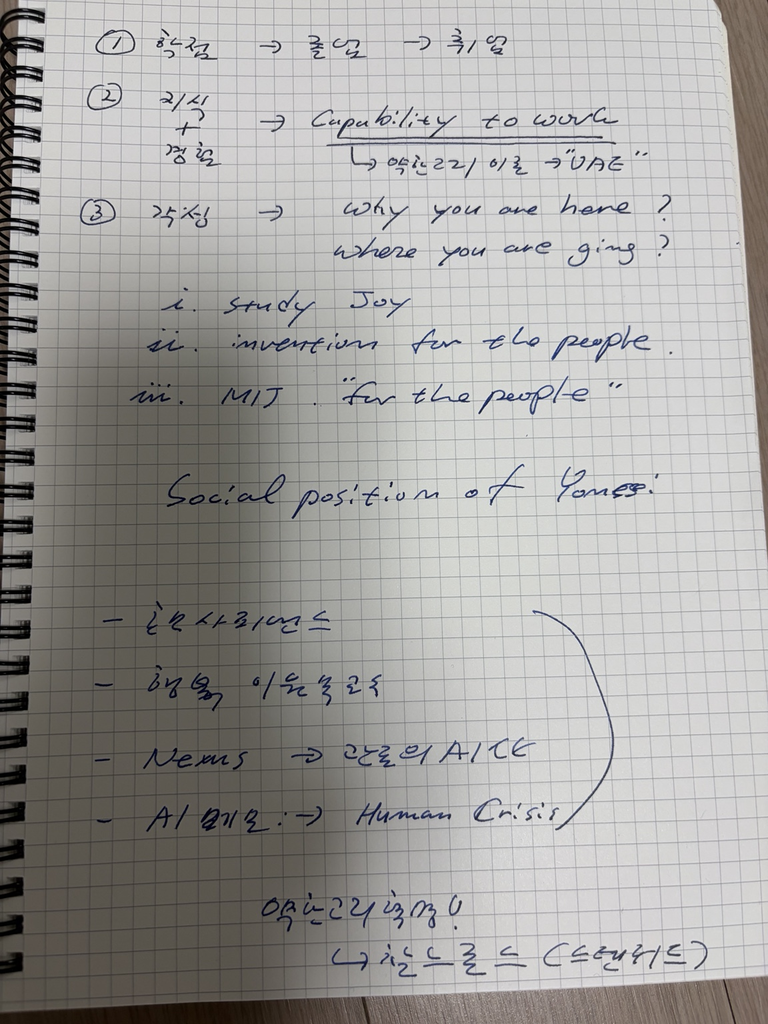

김임환 강의 구상 메모 원본

## Why are you here? Where are you going?

학점과 취업 이후에도  
남는 배움은 무엇일까요?

30초 동안 자신의 답을 생각해 봅시다.

교육과 경험5–8분

## 학교에서 만드는 것은 문제 해결 경험입니다

정답을 아는 것에 더해,  
정답이 없는 상황을 다루는 연습이 필요합니다.

01

### 이론

원리와 가정을 이해한다

02

### 실험

예상과 다른 결과를 만난다

03

### 수정

원인을 좁히고 다시 검증한다

04

### 설명

근거를 남기고 타인에게 전달한다

교육과 경험8–12분

## 회사는 경험이 만든 역량에 비용을 지불합니다

| 면접에서 묻는 것 | 경험으로 보여 줄 수 있는 것 |
| --- | --- |
| 무엇을 아는가 | 원리와 조건을 정확히 설명한다 |
| 무엇을 해결했는가 | 실패 원인을 좁히고 해결 근거를 제시한다 |
| 다음에도 할 수 있는가 | 방법을 기록하고 재현할 수 있다 |
| 함께 일할 수 있는가 | 불확실성과 한계를 팀에 전달한다 |

개인의 경험은 역량이 되고,  
공유 가능한 기록은 조직의 자산이 됩니다.

경험과 데이터12–14분

## 경험은 기록할 때 학습 가능한 데이터가 됩니다

01

### 상황

무슨 문제였나?  
조건은 무엇이었나?

02

### 행동

무엇을 바꿨나?  
왜 그렇게 했나?

03

### 결과

무엇을 측정했나?  
예상과 얼마나 달랐나?

04

### 검증

다시 해도 같은가?  
다른 원인은 없나?

경험을 모두 데이터로 남길 수는 없습니다.  
측정과 해석의 품질이 자산 가치를 결정합니다.

경험과 데이터14–17분

## Silver와 Sutton이 말하는 경험의 시대

Welcome to the  
Era of Experience

### 기존 자료에서 학습

사람이 남긴 문서와 답을 학습한다

### 환경과 상호작용

행동하고 결과를 관찰하며 배운다

환경은 실제 세계뿐 아니라  
시뮬레이터와 코드 실행 환경도 포함합니다.

경험과 데이터17–20분

## 반도체 설계 사례: 특정 비아의 불량 가설

| 단계 | 설계 대학원생이 하는 일 |
| --- | --- |
| 관찰 | 특정 위치에 실패가 반복되는지 확인 |
| 가설 | 비아 구조 또는 공정 조건의 영향을 의심 |
| AI 활용 | 진단 후보와 물리적 위치의 공통점을 분석 |
| 검증 | 추가 측정과 물리적 불량 분석으로 확인 |

AI의 후보 순위는 원인의 확정과 다릅니다.

AI와 조직20–23분

## 『Nexus』: 정보는 사회의 질서를 만듭니다

NEXUS

유발 하라리 · 2024

### 정보와 진실

정보가 많아져도 진실이 자동으로 늘지는 않는다

### 정보와 권력

분류와 규칙은 사람의 기회와 행동을 바꾼다

AI와 조직23–26분

## AI는 관료적 업무를 수행할 수 있습니다

| 기존 업무 | AI가 맡을 수 있는 역할 | 사람에게 미치는 영향 |
| --- | --- | --- |
| 보고서 읽기 | 핵심 내용 분류 | 어떤 정보가 주목받는가 |
| 일정·자원 배분 | 우선순위 추천 | 누가 기회를 얻는가 |
| 규정 적용 | 조건에 따른 승인 제안 | 누가 배제되는가 |
| 성과 평가 | 지표를 계산하고 비교 | 무엇을 잘한 일로 보는가 |

AI와 조직26–28분

## AI 판단에 이의를 제기할 수 있어야 합니다

“AI가 그렇게 판단했습니다.”  
이 설명만으로 충분할까요?

01

판단에 사용한 조건과 자료를 확인할 수 있는가

02

잘못된 자료와 예외 상황을 수정할 수 있는가

03

책임 있는 사람이 재검토하고 결정을 바꿀 수 있는가

AI 활용의 선택28–31분

## Bill Gates: 여러 작업을 수행하는 AI 에이전트

### 대화형 도구

질문에 답하고 초안을 만든다

### 에이전트

목표에 따라 도구를 연결하고 작업을 수행한다

01

교육: 학습 상황에 맞춘 지원

02

업무: 자료를 정리하고 다음 행동을 준비

Gates Notes의 2023년 글 두 편을 바탕으로 한 요약

AI 활용의 선택31–35분

## 설계 업무를 어떻게 나눌 것인가

| 업무 | AI 활용 | 사람의 역할 |
| --- | --- | --- |
| 문헌 조사 | 논문 후보와 요약 | 원문·주장·출처 확인 |
| 시뮬레이션 코드 | 초안과 반복 작업 | 물리적 가정·범위 설정 |
| 실험 후보 비교 | 성능·비용의 후보 탐색 | 목표·제약·검증 설계 |
| 중요한 최종 결정 | 근거와 대안 준비 | 책임을 맡고 결정 |

토론: 내 연구에서 줄일 반복 작업 하나와  
직접 남길 판단 하나는 무엇인가?

학습 데이터의 한계35–37분

## 사전학습의 한계와 LLM의 미래

Ilya Sutskever의 2024년 강연은  
기존 사전학습 방식의 변화 가능성을 제기했습니다.

### 사전학습

대규모 기존 자료로 기본 능력을 학습하는 과정

### 다음 질문

새로운 학습 신호를 어디에서 얻을 것인가

특정 방식의 한계를 LLM 전체의 종말로 일반화할 수는 없습니다.

학습 데이터의 한계37–40분

## 합성 데이터의 위험과 활용 조건

| 위험이 커지는 경우 | 개선 가능성을 만드는 조건 |
| --- | --- |
| 기존 자료를 생성물로 계속 대체 | 원본 자료를 유지하고 함께 누적 |
| 오류를 확인하지 않고 재학습 | 실행·측정·외부 검증으로 오류 확인 |
| 드문 사례가 반복해서 사라짐 | 대표성과 실패 사례를 별도로 점검 |

AI가 만들었다는 이유만으로 데이터의 가치를 판단할 수는 없습니다.

학습 데이터의 한계40–42분

## 경험의 가치는 결과를 확인할 때 생깁니다

01

### 목표

전력과 지연의  
기준을 정한다

02

### 행동

설계 후보를  
바꿔 본다

03

### 피드백

시뮬레이션 결과를  
확인한다

04

### 갱신

다음 후보와  
가설을 수정한다

시뮬레이터에서 좋은 결과도  
실제 칩의 측정으로 다시 확인해야 합니다.

공장 자동화 사례42–46분

## 『American Factory』: 일자리의 기대와 변화

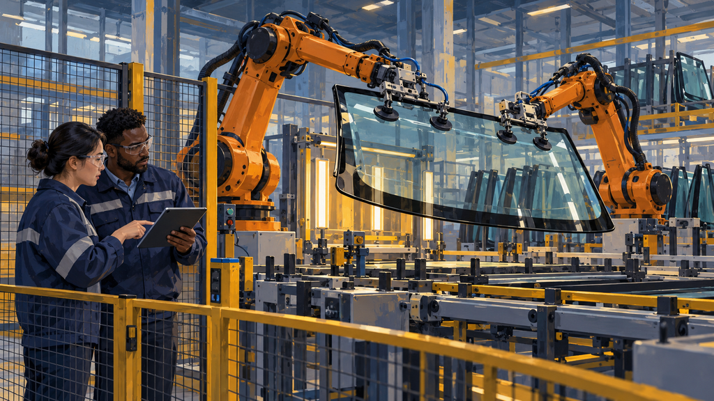

강의용 생성 일러스트 · 실제 다큐 장면이 아닙니다

### American Factory 2019

중국 기업이 미국 오하이오의  
폐쇄 공장을 다시 엽니다.

문화와 노동 방식의 충돌,  
자동화가 던지는 질문을 살펴봅니다.

[Netflix 공식 소개·예고편 열기](https://www.netflix.com/kr-en/title/81090071)

공장 자동화 사례46–49분

## 생산성의 이익이 모두에게 돌아가지는 않습니다

| 관점 | 기대하는 이익 | 현실에서 검토할 비용 |
| --- | --- | --- |
| 기업 | 생산성과 품질 개선 | 투자·유지보수·통합 비용 |
| 노동자 | 위험하고 반복적인 일 감소 | 일자리·소득·재교육 부담 |
| 지역사회 | 생산 기반과 경쟁력 | 고용 감소와 전환 지원 |

자동화의 총효과와 이익의 분배는  
서로 다른 질문입니다.

사람을 위한 기술49–52분

## 돌봄에서 사람이 함께한다는 것의 가치

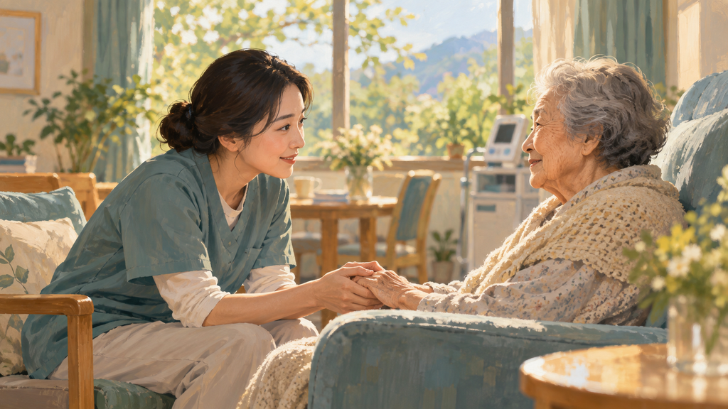

강의용 생성 일러스트: 돌봄의 관계

AI는 기록과 일정,  
보조 업무를 도울 수 있습니다.

상대의 말을 듣고,  
선택을 존중하고,  
책임 있게 곁에 있는 일은  
어떻게 지킬까요?

사람을 위한 기술52–54분

## ‘사람을 위한 보호영역’이라는 제안

자연보호구역처럼,  
자동화가 가능해도 인간의 참여를 보장할 영역을 생각합니다.

| 영역 | AI의 지원 | 사람의 참여를 보장할 이유 |
| --- | --- | --- |
| 교육·멘토링 | 자료와 개별 연습 | 성장 과정에서의 관계 |
| 돌봄·상담 | 기록과 보조 업무 | 당사자의 선택과 신뢰 |
| 중요한 평가 | 근거와 후보 준비 | 책임과 이의 제기 |

이 비유는 강의자의 제안이며 특정 저자의 공식 용어가 아닙니다.

공학자의 목적54–55분

## “내가 해결할 수 있다”는 감각

Self-efficacy

자기효능감: 특정 과제를  
해낼 수 있다고 믿는 감각

직접 해결한 경험은  
다음 도전을 시작할 근거가 됩니다.

공학자의 목적55–56분

## 일의 의미를 만드는 동기의 조건

### 자율성

내가 선택하고 있다는 감각

### 유능감

능력이 커지고 있다는 감각

### 관계성

다른 사람과 연결되어 있다는 감각

외부의 인정은 도움이 될 수 있습니다.  
지속적인 동기에는 스스로의 선택과 성장도 중요합니다.

공학자의 목적56–58분

## MIT의 미션: 지식과 발견을 인류의 발전에

“for the betterment  
of humankind”

인류의 더 나은 삶을 위해

### Mens et Manus

Mind and Hand · 정신과 손

### 공학도의 질문

이 연구는 누구의 삶을 어떻게 개선하는가?

마지막 2분58–58.5분

## 나의 자산: 도메인과 검증 가능한 경험

메모의 생각을  
연구 행동으로 옮깁니다.

01

깊게 이해할 분야를 정한다

02

검증할 문제와 방법을 남긴다

03

AI를 써서 탐색과 정리를 개선한다

자산은 단순한 데이터의 양보다  
다시 활용할 수 있는 근거입니다.

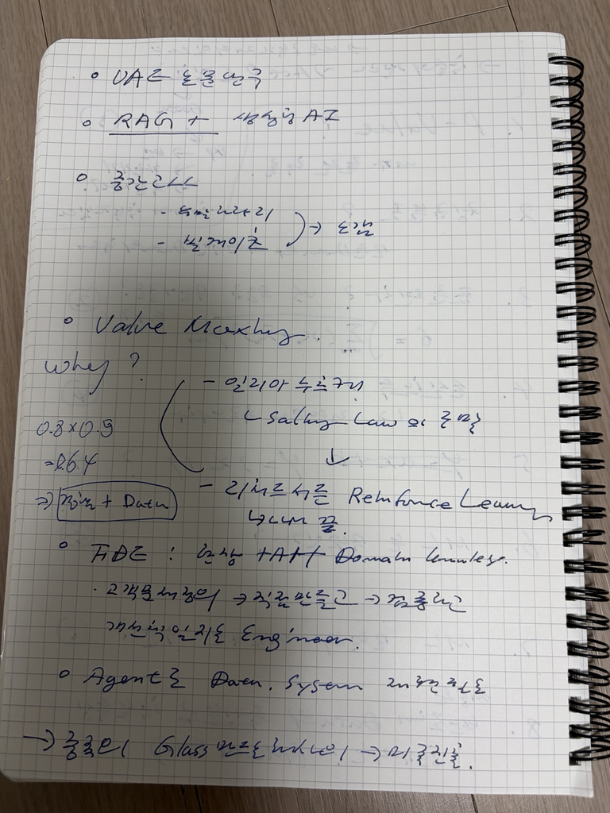

김임환 강의 구상 메모 원본

마지막 2분58.5–59.5분

## 1분 작성: 이번 학기에 만들 나의 경험

| 질문 | 한 문장으로 적어 봅시다 |
| --- | --- |
| My Domain | 깊게 이해하고 싶은 반도체 분야는? |
| My Problem | 아직 설명되지 않은 문제 하나는? |
| My Experience | 직접 해 볼 실험이나 분석은? |
| My Data | 어떤 조건·행동·결과를 기록할 것인가? |
| My Purpose | 그 결과는 누구에게 도움이 되는가? |

마지막 2분59.5–60분

## 경험을 만들고, 근거를 남기고, 목적을 묻습니다

현장에서 문제를 발견하고  
AI와 함께 답을 검증하는  
공학자가 됩시다.

이번 주의 실행: 질문 하나, 실험 하나, 기록 한 장

그리고 마지막 질문  
“이 기술은 결국 누구를 위한 것인가?”

참고자료강의 후 참고

## 참고자료 1: AI·정보망·경험 학습

### Harari, Nexus (2024), 저자 공식 소개

https://www.ynharari.com/book/nexus/

### Bill Gates, The Age of AI Has Begun (2023)

https://www.gatesnotes.com/The-Age-of-AI-Has-Begun

### Bill Gates, AI Agents (2023)

https://www.gatesnotes.com/AI-agents

### Silver & Sutton, Welcome to the Era of Experience (2025), pp. 1–3, 7–8

https://storage.googleapis.com/deepmind-media/Era-of-Experience%20/The%20Era%20of%20Experience%20Paper.pdf

### Shumailov et al., Nature 631, 755–759 (2024)

https://doi.org/10.1038/s41586-024-07566-y

### Gerstgrasser et al., Is Model Collapse Inevitable? (2024)

https://arxiv.org/abs/2404.01413

참고자료강의 후 참고

## 참고자료 2: 사례·교육·목적

### American Factory (2019), Netflix 공식 소개·예고편

https://www.netflix.com/kr-en/title/81090071

### Bandura (1977), Self-efficacy, doi:10.1037/0033-295X.84.2.191 / APA 해설

https://www.apa.org/research-practice/conduct-research/self-efficacy-human-agency.html

### Ryan & Deci, 자기결정이론 공식 소개

https://selfdeterminationtheory.org/the-theory/

### MIT 공식 Mission Statement

https://www.mit.edu/about/mission-statement/

### Sutskever, NeurIPS 2024 수상 강연 / 발언 확인: Reuters, 2024-12-14

https://www.reuters.com/technology/artificial-intelligence/ai-with-reasoning-power-will-be-less-predictable-ilya-sutskever-says-2024-12-14/

그림: 제공된 메모 원본 2장 + 강의용 생성 일러스트 3장  
반도체 비아 사례: 교육용 가상 예시

좌우 방향키로 넘기세요. 수정한 내용은 HTML 저장으로 보관하세요.16:9 · 본문 25장 + 참고자료 2장 · 60분

Esc 키로 발표 종료